# HW: Data Visualization with ggplot

Yixing Wang

2025-11-09

All questions should be answered using ggplot package. Show your code and the figure in the same order. Add complete annotation to every plot( coordinate labeling and title)

Load the ggplot2 and fueleconomy packages, as well as the vehicles dataset.

```r
library(ggplot2)
library(fueleconomy)
head(vehicles,2)
```

```
## # A tibble: 2 × 12
##      id make  model        year class  trans drive   cyl displ fuel    hwy   cty
##   <dbl> <chr> <chr>       <dbl> <chr>  <chr> <chr> <dbl> <dbl> <chr> <dbl> <dbl>
## 1 13309 Acura 2.2CL/3.0CL  1997 Subco… Auto… Fron…     4   2.2 Regu…    26    20
## 2 13310 Acura 2.2CL/3.0CL  1997 Subco… Manu… Fron…     4   2.2 Regu…    28    22
```

# 1.

Make a scatterplot of `hwy` vs. `cty`.

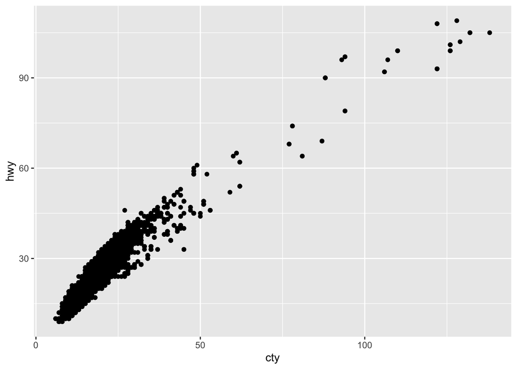

```r
# insert your code
ggplot(data = vehicles, mapping = aes(x = cty, y = hwy)) +
  geom_point()
```

# 2.

Convert the `cyl` column to a factor.

```r
library(dplyr)
vehicles <- vehicles %>%
  mutate(cyl = factor(cyl))
```

# 3.

Modify the plot from Question 1 such that the color of the dot represents `cyl` value. Set `col=cyl`. then repeat with adding the line: `scale_color_brewer(palette = "YlOrRd")`

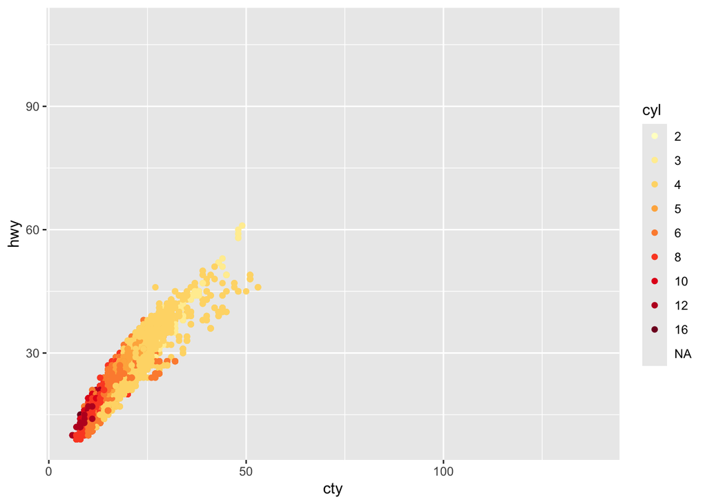

```r
ggplot(data = vehicles, mapping = aes(x = cty, y = hwy, color = cyl)) +
  geom_point() +
  scale_color_brewer(palette = "YlOrRd")
```

# 4.

There is a lot of overplotting in the plot above. Remove the color scale and modify the previous plot so that alpha = 0.1.

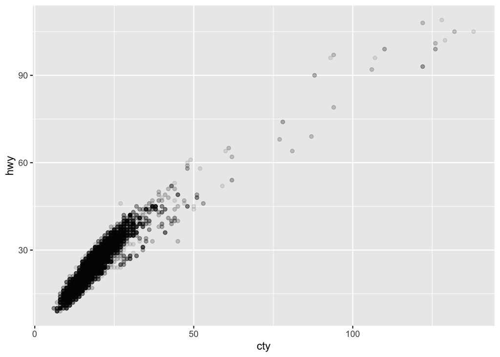

```r
ggplot(data = vehicles, mapping = aes(x = cty, y = hwy)) +
  geom_point(alpha = 0.1)
```

# 5.

Make a histogram of year.

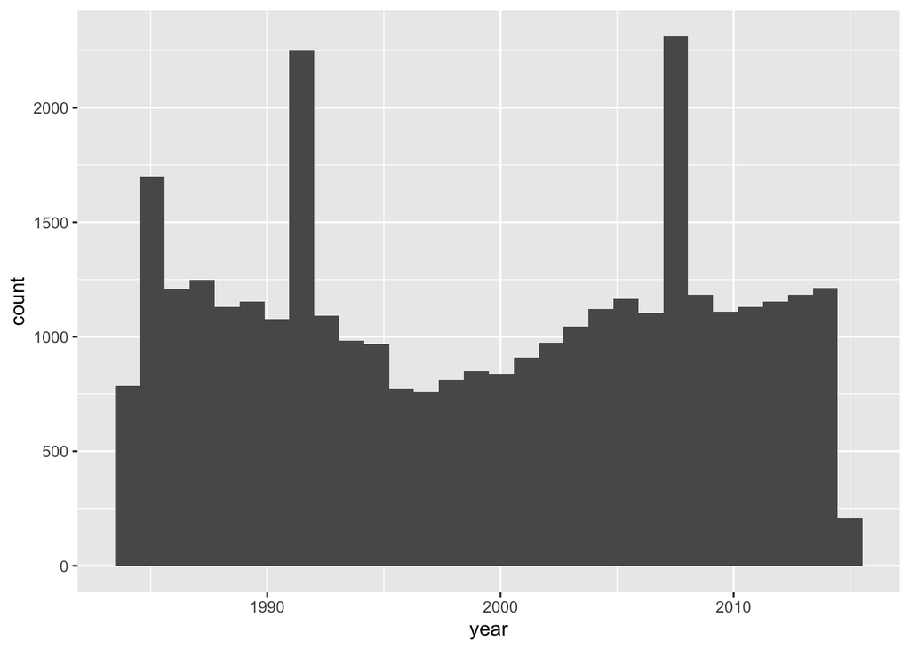

```r
ggplot(data = vehicles, mapping = aes(x = year)) +
  geom_histogram()
```

# 6.

Make a histogram of year with just 5 bins.

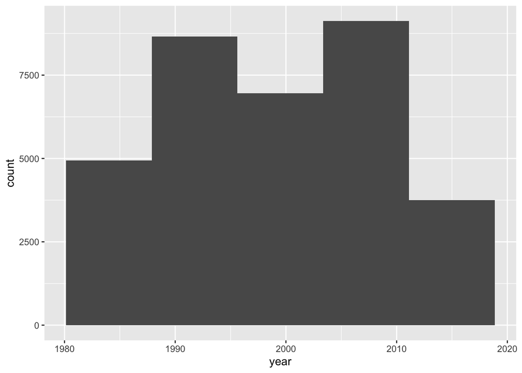

```r
ggplot(data = vehicles, mapping = aes(x = year)) +
  geom_histogram(bins = 5)
```

# 7.

For each value of cyl, make a violin plot of hwy values.

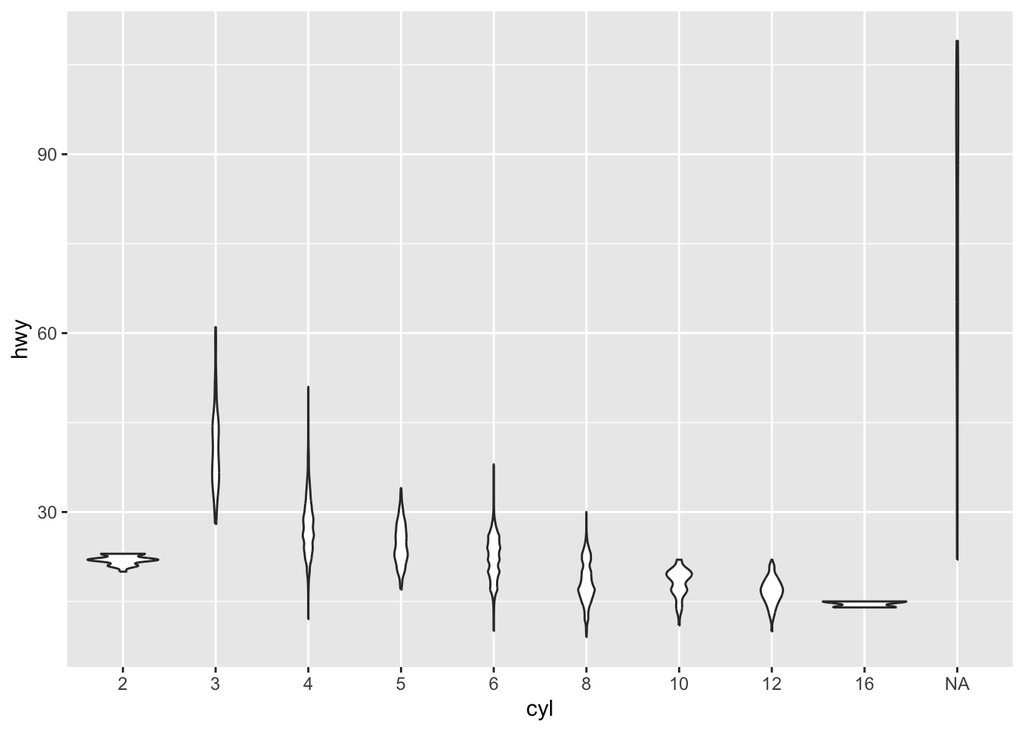

```r
ggplot(data = vehicles, mapping = aes(x = cyl, y = hwy)) +
  geom_violin()
```

# 8.

For each value of cyl, make a boxplot of hwy values.

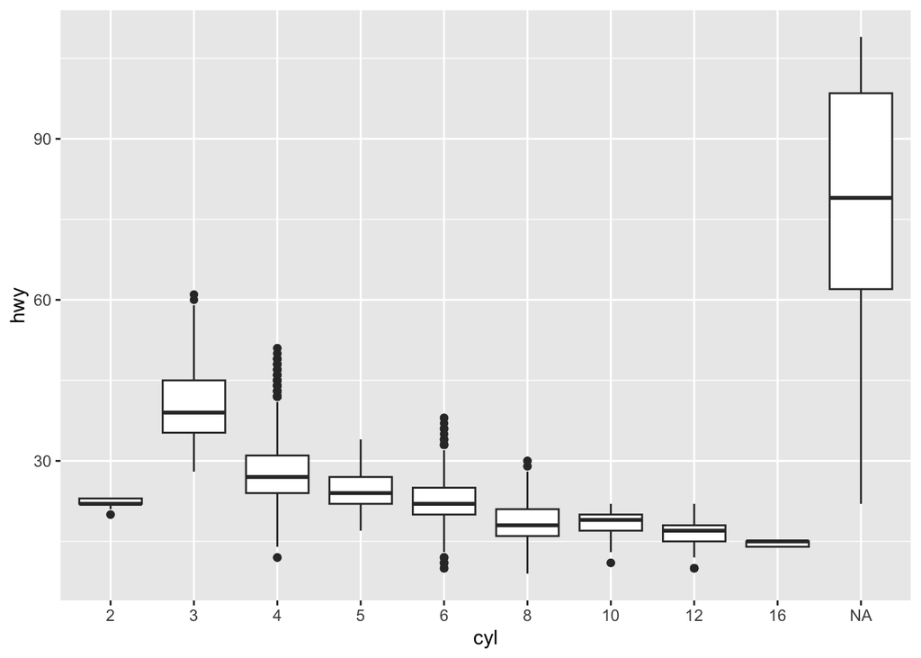

```r
ggplot(data = vehicles, mapping = aes(x = cyl, y = hwy)) +
  geom_boxplot()
```

# 9.

Make a barplot to show how many cars of each type of fuel there are in the dataset. (Hint: Use the geom_bar geom.)

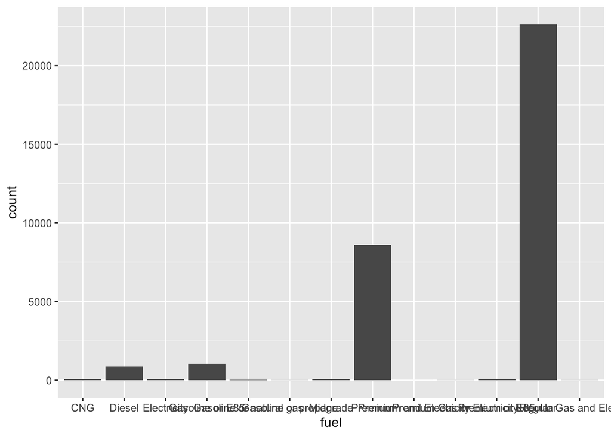

```r
ggplot(data = vehicles, mapping = aes(x = fuel)) +
  geom_bar()
```

# 10.

Add a coord_flip() layer to the previous plot to make a horizontal barplot.

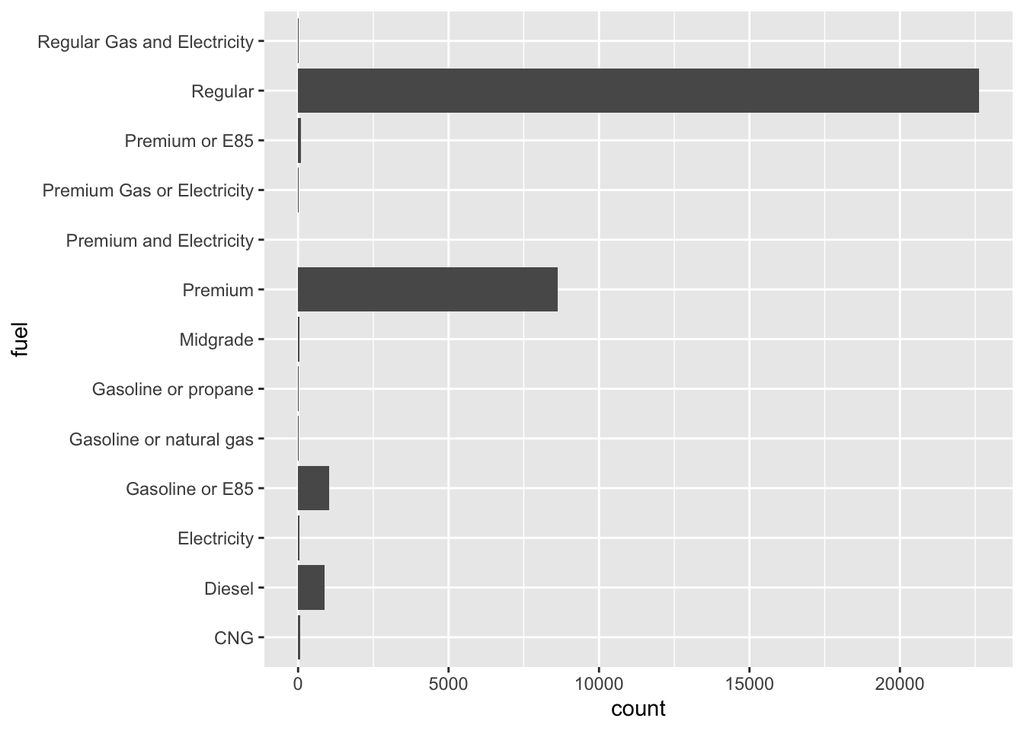

```r
ggplot(data = vehicles, mapping = aes(x = fuel)) +
  geom_bar() +
  coord_flip()
```

# 11.

Make a scatterplot of hwy vs. cty. Give axis titles and a main title to the plot to make it more interpretable.

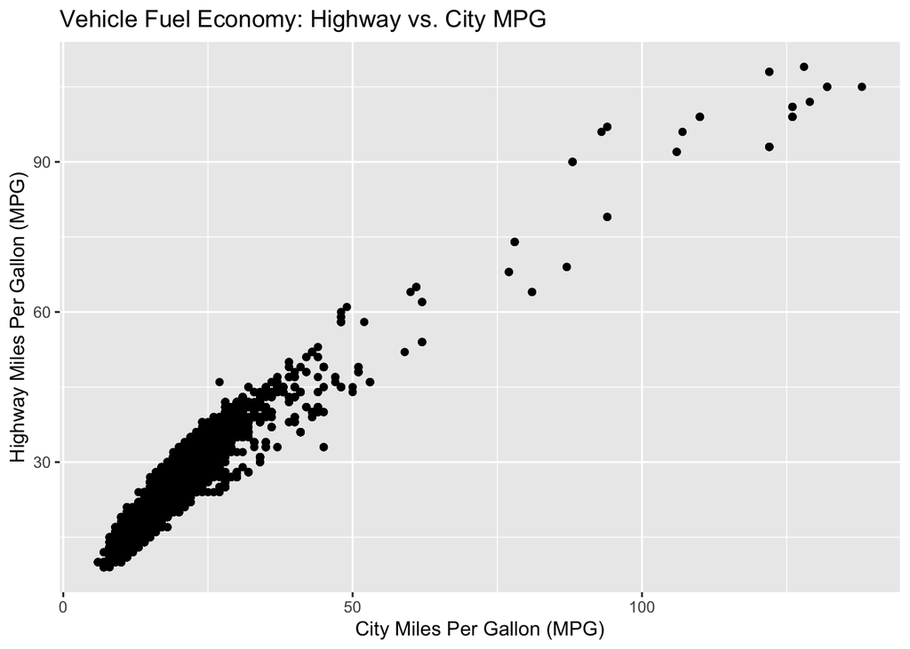

```r
ggplot(data = vehicles, mapping = aes(x = cty, y = hwy)) +
  geom_point() +
  labs(
    title = "Vehicle Fuel Economy: Highway vs. City MPG",
    x = "City Miles Per Gallon (MPG)",
    y = "Highway Miles Per Gallon (MPG)"
  )
```

# 12.

Modify the plot above such that the color of the dot represents cyl value. Also reduce the alpha of the points to an appropriate level and introduce jitter.

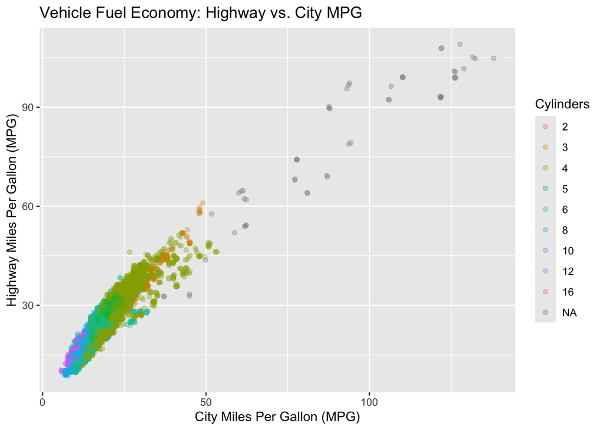

```r
ggplot(data = vehicles, mapping = aes(x = cty, y = hwy, color = cyl)) +
  geom_jitter(alpha = 0.3) +
  labs(
    title = "Vehicle Fuel Economy: Highway vs. City MPG",
    x = "City Miles Per Gallon (MPG)",
    y = "Highway Miles Per Gallon (MPG)",
    color = "Cylinders"
  )
```

# 13.

Modify the plot above so that each value of cyl is in its own plot. (hint add: facet_wrap(~ cyl))

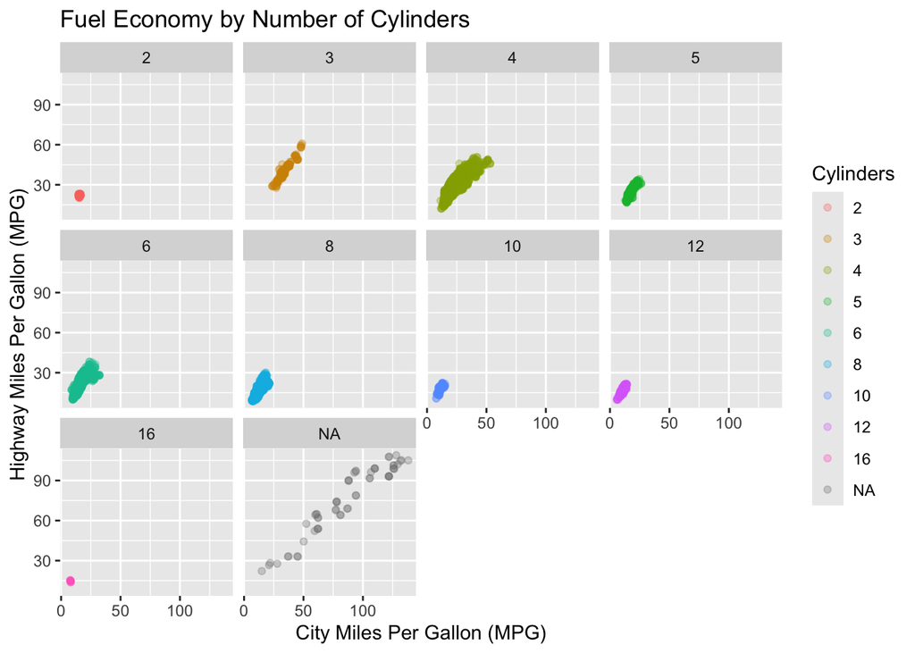

```r
ggplot(data = vehicles, mapping = aes(x = cty, y = hwy, color = cyl)) +
  geom_jitter(alpha = 0.3) +
  labs(
    title = "Fuel Economy by Number of Cylinders",
    x = "City Miles Per Gallon (MPG)",
    y = "Highway Miles Per Gallon (MPG)",
    color = "Cylinders"
  ) +
  facet_wrap(~ cyl)
```

# 14.

While the plot above gives us a good idea of how cars with different cyl values compare with each other, a lot of the plot space is wasted. Modify the plot so that each little plot has its own x and y scale. (Hint: This website might be helpful.)

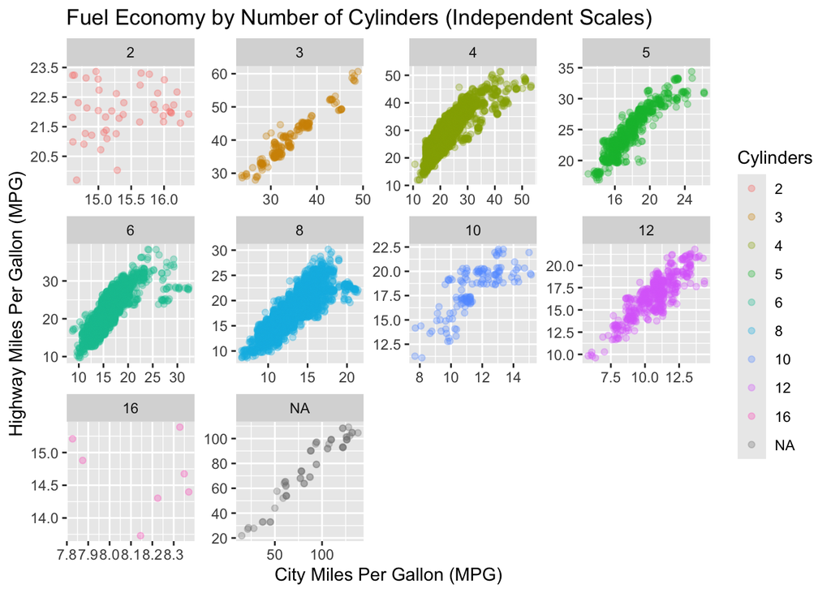

```r
ggplot(data = vehicles, mapping = aes(x = cty, y = hwy, color = cyl)) +
  geom_jitter(alpha = 0.3) +
  labs(
    title = "Fuel Economy by Number of Cylinders (Independent Scales)",
    x = "City Miles Per Gallon (MPG)",
    y = "Highway Miles Per Gallon (MPG)",
    color = "Cylinders"
  ) +

  facet_wrap(~ cyl, scales = "free")
```

# 15.

Make a barplot to show how many cars of each type of fuel there are in the dataset. (Use the geom_bar geom.) Change the theme to ggplot’s black and white theme.

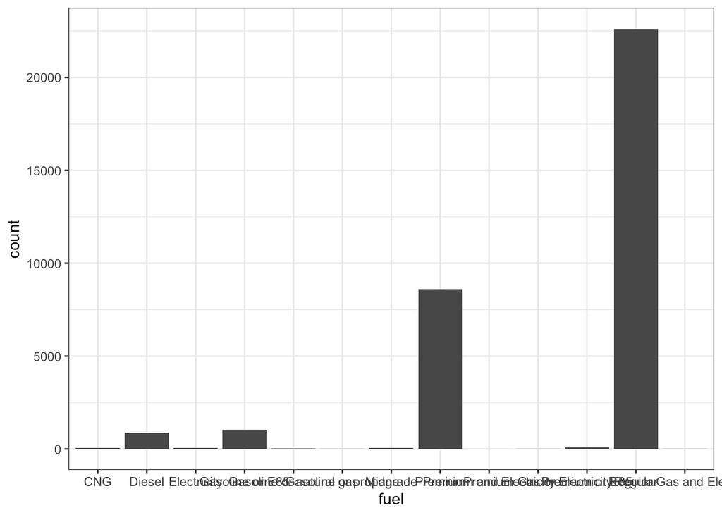

```r
ggplot(data = vehicles, mapping = aes(x = fuel)) +
  geom_bar() +
  theme_bw()
```

# 16.

Make a violin plot to show the distribution of displ for each value of drive. Overlay that with a scatterplot of displ vs. drive (with jitter and alpha).

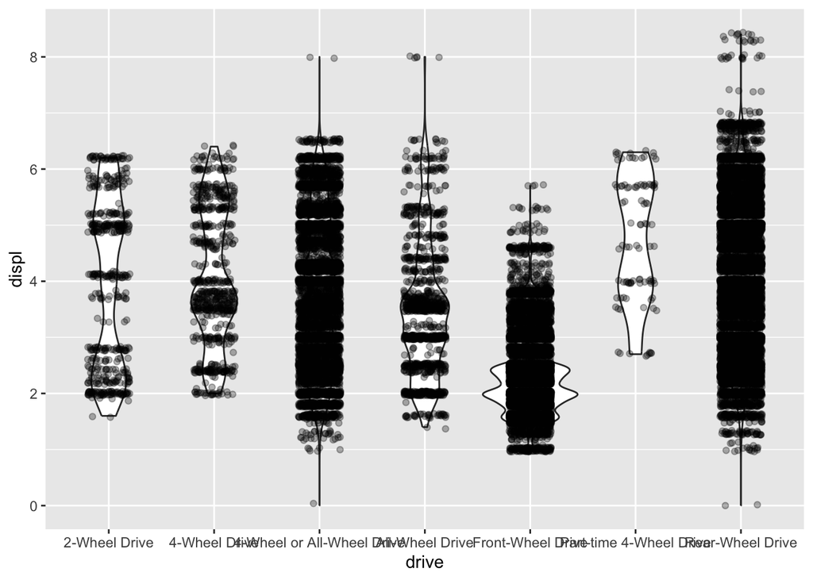

```r
ggplot(data = vehicles, mapping = aes(x = drive,y=displ)) +
  geom_violin() +
  geom_jitter(alpha = 0.3,width = 0.2)
```